# مشكلة البحث والفروض

مناهج البحث الاجتماعي · الفصل الثاني

د. فاطمة القبندي · جامعة الكويت

23 سبتمبر 2026

## المحاضرة الأولى: من الادعاء إلى سؤال قابل للبحث

**استرجاع من الفصل الأول**

ما الدليل؟ كيف عرفنا؟ وهل يوجد تفسير آخر؟

الاثنين ٢١ سبتمبر

## هل يكفي هذا الادعاء لبدء بحث؟

«إذا شعر الطالب أن رأيه يخالف الرأي السائد في مجموعة طلابية، فسوف يلتزم الصمت.»

**الادعاء (Claim):** عبارة تقول إن شيئًا ما صحيح، أو تتوقع علاقة؛ وهي تحتاج إلى دليل، ولا تُعد دليلًا بحد ذاتها.

قبل جمع أي بيانات، نحتاج إلى أن نسأل:

- كيف سنعرف **الرأي السائد**؟
- ماذا نعني بـ **الصمت أو التعبير**؟
- أي طلبة وأي مجموعات نقصد؟
- هل نتوقع علاقة أم أثرًا سببيًا؟

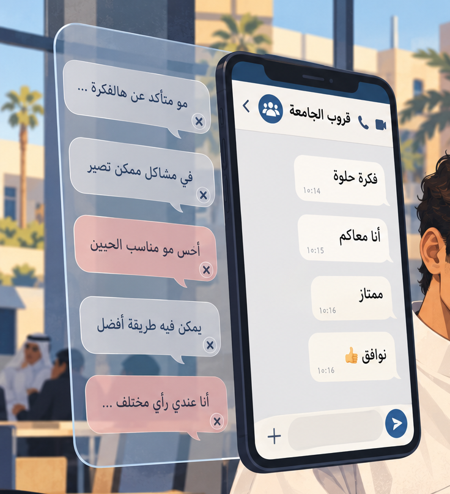

## البيانات لا تتحدث وحدها

البحث العلمي ليس جمع أكبر كمية ممكنة من المعلومات؛ بل جمع **البيانات المناسبة** للإجابة عن **سؤال محدد**.

فكرة مبدئية

←

سؤال يعمل كمرشّح

←

بيانات نحتاج إليها

«إذا لم تكن لدينا فكرة تقودنا، فلن نعرف ما الحقائق التي ينبغي جمعها» (Cohen, 1956, p. 148، كما ورد في كتاب الفصل).

## الموضوع الواسع ليس مشكلة بحث

مجال واسع: التعبير عن الرأي عبر الإنترنت

ظاهرة: الصمت في المجموعات الطلابية

مشكلة: لا نعرف كيف يرتبط إدراك الرأي السائد بقرار التعبير

سؤال محدد قابل للبحث

المشكلة البحثية تحدد ما نريد أن نعرفه، لا المجال الذي نهتم به فقط.

## من أين تأتي المشكلات البحثية؟

- ملاحظة ظاهرة اجتماعية
- خبرة الباحث الأكاديمية أو المهنية
- وسائل الإعلام والنقاش العام
- الكتب والدوريات العلمية
- نتائج دراسة سابقة
- حاجة مؤسسة أو جهة ممولة

المصدر يولّد الفكرة، لكن الأدبيات تصقلها.

## البحث حلقة في سلسلة

تساعد مراجعة الدراسات السابقة على معرفة:

- ما الذي نعرفه بالفعل؟
- كيف عُرّفت المفاهيم وقِيست؟
- ما النظريات والفروض المستخدمة؟
- ما الأخطاء والحدود التي ظهرت؟
- ما السؤال الذي بقي بلا جواب؟

لا يبدأ العلم من الصفر، ولا يكرر ما سبقه بلا إضافة.

سنعود في الفصل الثالث إلى كيفية بناء مراجعة أدبيات مترابطة؛ المطلوب هنا هو تحديد موقع السؤال داخل المعرفة المتاحة.

## كيف تحدد مراجعة الأدبيات الفجوة البحثية؟

Literature Review

لا تكفي عبارة: **«لم أجد دراسة مطابقة تمامًا»**.

قد تظهر الفجوة عندما:

- تتعارض نتائج الدراسات السابقة
- لا يشمل الدليل مجتمعًا أو سياقًا مهمًا
- تستخدم الدراسات مقياسًا محدودًا
- يبقى تفسير بديل بلا اختبار
- تتغير الظاهرة ويحتاج الدليل إلى تحديث

الفجوة = سؤال مهم لا يجيب عنه الدليل المتاح بصورة كافية

## الأصالة ليست اختراع موضوع جديد

قد تأتي الإضافة من:

- سؤال أو تفسير مختلف
- مجتمع أو سياق لم يُدرس جيدًا
- مقياس أو منهج أنسب
- عينة أو وحدة تحليل مختلفة
- اختبار حدّ من حدود نتيجة سابقة
- تكرار منهجي يفحص إمكان إعادة النتيجة

الصمت عبر الإنترنت ليس موضوعًا جديدًا، لكن دراسة **مناخ الرأي داخل الموقف نفسه** وقرار نشر تعليق في مجموعة طلابية بجامعة الكويت قد تقدم إضافة محددة.

## بحث أساسي أم تطبيقي؟

**البحث الأساسي**

Basic Research

يطوّر المعرفة أو يختبر تفسيرًا نظريًا.

**البحث التطبيقي**

Applied Research

يعالج مشكلة عملية أو يساعد في قرار أو برنامج.

قد يجمع البحث الجيد بين إسهام علمي وفائدة عملية.

## مشروعنا المتكرر: قرار قبل البيانات

نريد دراسة إدراك مناخ الرأي والاستعداد للتعبير في المجموعات الطلابية لدى طلبة جامعة الكويت.

**ما الغرض الأساسي؟**

1. فهم العلاقة وتطوير تفسير عن الصمت؟
2. مساعدة الجامعة في تصميم مساحات نقاش أكثر أمانًا؟
3. الجمع بين الهدفين؟

تحديد الغرض يغيّر السؤال، والبيانات، وحدود النتيجة.

## أفضل صياغة تبدأ بسؤال

مشكلة البحث الجيدة:

- واضحة ومحددة
- تتضمن المتغيرات او المفاهيم أو الظاهرة المقصودة
- قابلة للدراسة ميدانيًا
- تحدد المجتمع والسياق عند الحاجة
- لا تفترض الجواب مسبقًا

مشكلة واسعة ← سؤال محدد قابل للبحث

## مثال: من إحصاءات الجريمة إلى مشكلة بحث

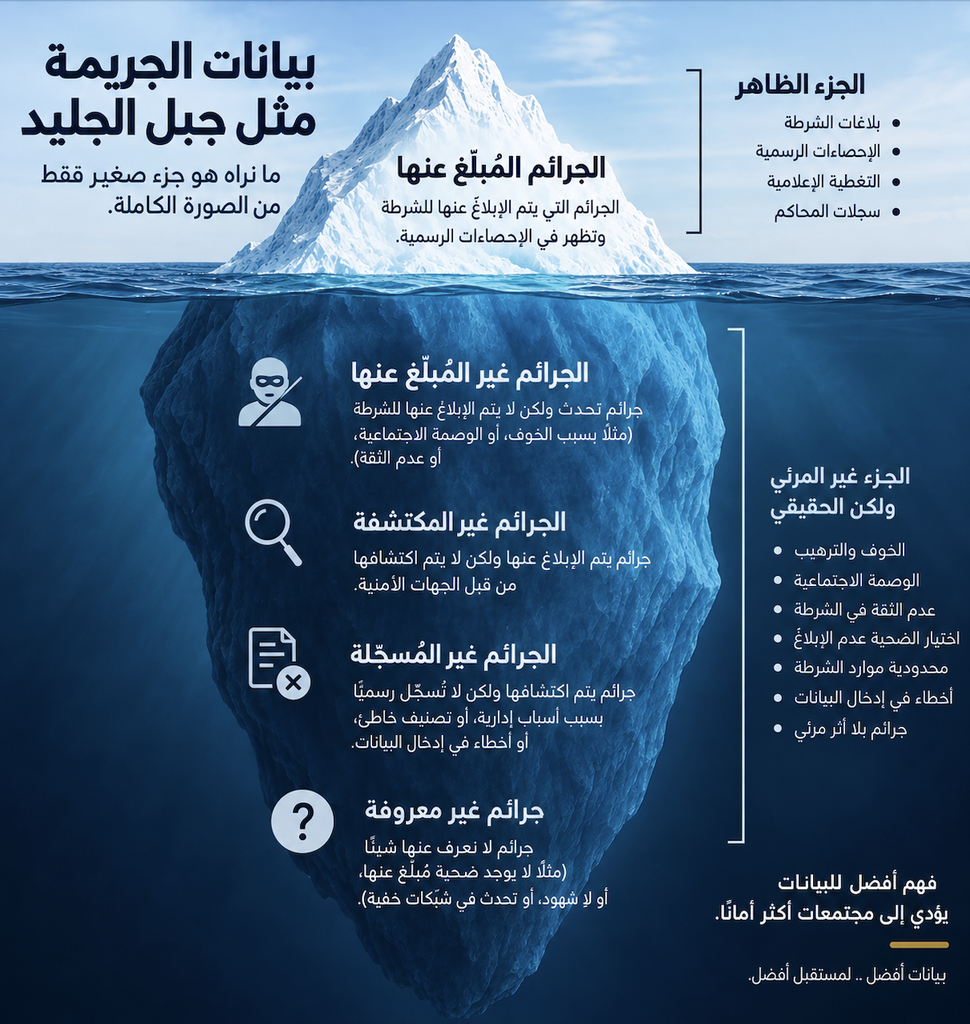

إلى أي مدى تختلف معدلات التعرض للجريمة التي يذكرها السكان عن المعدلات المسجلة رسميًا خلال عام؟

كل مصدر يرى جزءًا من الظاهرة؛ السؤال يحدد أي دليل نحتاج إليه.

**المسح (Survey):** طرح الأسئلة نفسها على مجموعة من الناس لجمع معلومات قابلة للمقارنة عن خبراتهم أو آرائهم.

## من ادعاء إلى سؤال قابل للبحث

**أ.** لماذا تُرهب مجموعات واتساب الطلبة وتجبرهم على الصمت؟

**ما رأيكم في هذا السؤال؟**

كيف تعيدون كتابته ليصبح سؤالًا أوضح وقابلًا للبحث؟

كيف ستجمعون المعلومات للإجابة عن سؤالكم المقترح؟ ممن؟ وما المعلومات التي تحتاجونها؟

**ب. مثال لسؤال بديل:** هل يرتبط شعور الطالب بأن رأيه مختلف عن أغلب أعضاء المجموعة باستعداده للمشاركة برأيه؟

طلبة جامعة الكويت · مجموعات واتساب الطلابية · الفصل الحالي

السؤال البديل يحدد ما ندرسه ويترك الجواب للبيانات.

## السؤال يرسم خريطة المتغيرات

هل يرتبط شعور الطالب بأن رأيه مختلف عن أغلب أعضاء المجموعة باستعداده للمشاركة برأيه؟ (طلبة جامعة الكويت · مجموعات واتساب الطلابية · الفصل الحالي)

**المتغير (Variable):** صفة أو مفهوم يختلف بين الأشخاص أو الحالات، مثل الاستعداد للمشاركة.

الشعور باختلاف الرأي (X) المتغير المفسِّر المتوقع

الاستعداد للمشاركة بالرأي النتيجة المبدئية (Y)

طلبة جامعة الكويت المجتمع

مجموعات واتساب الطلابية السياق · الزمن: الفصل الحالي

الشعور باختلاف الرأي ← علاقة محتملة ← الاستعداد للمشاركة

قد نختار لاحقًا دراسة **قرار نشر تعليق في موقف محاكًى**، ونعدّل السؤال والقياس وفقًا لذلك. وجود علاقة بين المتغيرات لا يثبت أن أحدهما سبب الآخر.

## تذكرة الخروج ١: من موضوع إلى سؤال

حوّلوا موضوع مجموعتكم إلى سؤال واحد يتضمن:

**مجتمعًا محددًا + مفهومًا أو علاقة + سياقًا أو زمنًا مناسبًا**

قبل التسليم: احذفوا أي كلمة تدين المشاركين أو تفترض الجواب.

## المحاضرة الثانية: هل نعتمد هذه المشكلة؟

**استرجاع**

ما الفرق بين الموضوع والمشكلة البحثية؟

الأربعاء ٢٣ سبتمبر

## الاختيار نفسه قرار منهجي

قيّموا كل سؤال بحسب وضع مشروعكم الآن.

**أخضر**

واضح وممكن

**أصفر**

يحتاج معلومات أو تعديلًا

**أحمر**

عائق أساسي

1. ما الذي سنعرفه ولم نكن نعرفه؟
2. من يستفيد من البحث؟
3. هل نستطيع الوصول إلى البيانات؟
4. هل لدينا الوقت والمهارات اللازمة؟
5. ما القيم أو المنظور الذي يوجّه اختيارنا؟
6. هل الموضوع حساس؟ وكيف قد يؤثر في المشاركين أو إجاباتهم؟
7. هل لدينا أداة تقيس ما نحتاج إليه؟
8. ما نطاق النتيجة؟ وعلى من يمكن أن تنطبق أو تُعمم؟
9. هل نستطيع حماية المشاركين والباحث؟
10. هل توجد قيود سياسية أو مؤسسية؟

مرّوا على القائمة لموضوع مجموعتكم. ما السؤال الأصعب في الإجابة؟ ولماذا؟

## القيم تحدد ما نراه مهمًا

قد تؤثر قيم الباحث ومدرسته الفكرية في:

- الموضوعات التي يختارها أو يهملها
- المفاهيم التي يركز عليها
- التفسير الذي يعدّه معقولًا
- طريقة قراءة النتائج

دراسة الجريمة قد تبدأ من الضبط الاجتماعي، أو عدم المساواة، أو خبرات الضحايا؛ وكل منظور يبرز أسئلة مختلفة.

## المنظور النظري يغيّر السؤال

**منظور الضبط الاجتماعي**

كيف تسهم القواعد والمؤسسات والعقوبات في الحد من الجريمة؟

**منظور الصراع**

كيف تؤثر القوة وعدم المساواة في تعريف الجريمة وتطبيق القانون؟

النظرية لا تقدم جوابًا فقط؛ بل تحدد ما نراه مشكلة وما نبحث عنه بوصفه تفسيرًا.

## القيمة ليست فرضًا قابلًا للاختبار

**حكم قيمي**

«الطالب اللي يسكت في المجموعة جبان.»

لا تحدد البيانات وحدها إن كان الشيء «جيدًا» أو «سيئًا».

**ادعاء قابل للاختبار**

«يرتبط إدراك اختلاف الرأي بانخفاض أو ارتفاع مؤشر محدد للاستعداد للتعبير.»

الوعي بالقيم والتصريح بها أفضل من إخفائها داخل التحليل.

## هل نستطيع الوصول إلى البيانات؟

نفحص قبل البدء:

- هل البيانات موجودة ومسموح باستخدامها؟
- هل يمكن حماية السرية والخصوصية؟
- هل قد يسبب الموضوع ضررًا للمشاركين أو الباحث؟
- هل تسمح الجهة الممولة بالنشر المستقل؟

الوصول إلى البيانات ليس تفصيلًا إداريًا؛ قد يعيد تشكيل مشكلة البحث كلها.

## القيود المؤسسية والسياسية

قد يتعذر بحث سؤال مهم بسبب:

- حجب البيانات أو صعوبة التصريح بالوصول إليها
- منع نشر نتائج لا توافق مصلحة الجهة
- مخاطر قانونية أو مهنية أو شخصية

الأهمية العلمية لا تلغي مسؤولية حماية المشاركين والباحث.

تختلف القيود باختلاف المؤسسة والمجتمع والموضوع؛ ولا يجوز افتراضها بصورة واحدة في كل سياق.

## الإمكانات ترسم حدود المشروع

سؤال ممكن = وقت مناسب + تمويل كافٍ + مهارات متاحة + فريق قادر

قد نحتاج إلى:

- تدريب نظري أو منهجي أو إحصائي
- ميزانية للوصول إلى عينة أو موقع
- وقت لبناء الأداة وجمع البيانات
- شراكة تكمل مهارات الباحث

تقليص السؤال بوضوح أفضل من مشروع واسع لا يمكن إنجازه جيدًا.

## لقطة واحدة أم متابعة عبر الزمن؟

**دراسة مقطعية**

Cross-sectional

وقت واحد

أم

**دراسة طولية**

Longitudinal

١

٢

٣

المتابعة تكشف التغير والترتيب الزمني بصورة أفضل، لكنها تتطلب وقتًا وموارد أكبر.

## الناس والأداة والباحث قد يغيّرون ما نرصده

**التفاعل مع الموضوع**

- الحساسية والخوف
- الرغبة في القبول الاجتماعي
- الأعراف والعلاقات

**التفاعل مع طريقة البحث**

- أثر الملاحظة
- مجاملة الباحث أو المحاور
- هوية من يسأل
- صياغة السؤال

الإجابة المسجلة قد تختلف عن الخبرة أو السلوك الفعلي؛ سنعود إلى وسائل الحد من هذه الآثار في الفصل الخامس.

## هل لدينا أداة مناسبة؟

قبل اختيار المشكلة، نسأل:

- هل يوجد مقياس ملائم للسياق واللغة؟
- هل يقيس المفهوم المقصود فعلًا؟ **الصدق**
- هل يعطي نتائج متسقة؟ **الثبات**
- هل تلائم المقابلة أو الملاحظة السؤال أكثر؟

الأداة تتبع السؤال؛ لا نختار السؤال لمجرد أن لدينا استبانة جاهزة.

هذه معاينة فقط؛ يعالج الفصل الرابع القياس والصدق والثبات بتفصيل أكبر.

## ما الذي سيضيفه البحث؟ ولمن؟

نفحص:

- **الفائدة العلمية:** هل يضيف إلى المعرفة؟
- **الفائدة العملية:** هل يساعد مجتمعًا أو قرارًا؟
- **المستفيدون:** من قد يستخدم النتيجة أو يتأثر بها؟
- **الاستقلال العلمي:** هل يمكن نشر النتيجة ولو كانت غير مرغوبة؟

قد يختبر البحث تفسيرًا عن مناخ الرأي، ويساعد في الوقت نفسه على تصميم نقاشات جامعية تشجع المشاركة وتحمي الخصوصية.

## نطاق البحث وحدود التعميم

Scope and Generalizability

يتحدد نطاق النتيجة وفق:

- المجتمع الذي يستهدفه السؤال
- طريقة اختيار العينة
- المكان والزمن والسياق

دراسة مقرر واحد قد تفيد ذلك المقرر، لكنها لا تمثل تلقائيًا جميع طلبة جامعة الكويت.

نعمم فقط إلى المجتمع الذي يستطيع تصميمنا تمثيله؛ وتأتي إجراءات المعاينة في الفصل السادس.

## ما وحدة التحليل؟

Unit of Analysis

المؤسسة

المجموعة أو المقرر

الفرد

ما الذي يمثّل **صفًا واحدًا** في البيانات؟

إذا كان السؤال عن سياسات الجامعات، فلا تكفي بيانات طلاب من جامعة واحدة لإجراء مقارنة بين المؤسسات.

## نقطة قرار: هل نعتمد المشكلة؟

المشروع: استبانة اختيارية في مقرر واحد عن مناخ الرأي والاستعداد للتعبير في المجموعات الطلابية.

| الأهمية | الوصول | الأخلاق | الوقت | البيانات |
| --- | --- | --- | --- | --- |
| ماذا سنضيف؟ | هل نصل للمشاركين؟ | هل نحميهم؟ | هل ننجز؟ | هل تقيس ما نحتاج؟ |

القرار: **نعتمد · نعدّل · لا نعتمد**؟ اذكروا أقوى مبرر وأخطر قيد.

## أربعة أغراض للدراسة

استكشاف ← وصف ← تفسير ← تقويم

- ماذا نحتاج إلى أن نفهم أولًا؟
- ماذا يحدث، ولدى من؟
- لماذا أو كيف يحدث؟
- هل نُفّذ البرنامج وحقق نتائجه؟

نوع السؤال يحدد نوع الدراسة، وما إذا كنا نحتاج إلى فرض.

## الدراسة الاستطلاعية: عمق بلا تعميم تلقائي

Exploratory Study

تُستخدم عندما تكون معرفتنا بالظاهرة محدودة، وتهدف إلى:

- فهم المشكلة واكتشاف أبعاد أو أسئلة جديدة
- تطوير فروض أو أداة لدراسة لاحقة
- فحص جدوى مشروع أوسع

تابع Snow وAnderson (1987) حياة ستة أشخاص بلا مأوى مدة عام: عمقٌ في فهم الخبرة، لا نسبةٌ تمثل جميع الأشخاص بلا مأوى.

## الدراسة الوصفية والتفسيرية

**وصفية** Descriptive

- ماذا يحدث؟ ومن؟ وأين؟ وكم؟
- تصف الانتشار والخصائص والأنماط
- قد تعرض علاقة، من دون تفسير سببها

**تفسيرية** Explanatory

- لماذا؟ وكيف؟
- تختبر فرضًا وتفحص تفسيرات بديلة
- تحتاج إلى تصميم يسمح بالاستنتاج المطلوب

الدلالة الإحصائية لا تثبت السببية؛ قوة التفسير تأتي من منطق التصميم والأدلة.

## الدراسة التقويمية

Evaluative Study

تفحص تنفيذ برنامج أو سياسة ونتائجها:

- هل طُبّق البرنامج كما خُطط له؟
- من استفاد منه؟
- هل تحققت النتائج المقصودة؟
- ما الآثار غير المقصودة؟

هل رفعت خاصية المشاركة المجهولة تنوع الآراء والمشاركة في نقاش طلابي؟

## اختاروا نوع الدراسة

صنّفوا كل سؤال:

1. كيف يصف الطلبة أسباب حذف تعليق قبل نشره؟
2. ما نسبة الطلبة الذين حذفوا تعليقًا بعد كتابته؟
3. لماذا يرتبط إدراك اختلاف الرأي بانخفاض الاستعداد للتعبير؟
4. هل رفعت المشاركة المجهولة تنوع الآراء في النقاش؟

استطلاعية ← وصفية ← تفسيرية ← تقويمية

## تذكرة الخروج ٢: أقوى مبرر وأخطر قيد

اكتبوا عن سؤال مجموعتكم:

1. غرض الدراسة: استكشافي، وصفي، تفسيري، أم تقويمي؟
2. أقوى مبرر لاعتماد المشكلة.
3. أخطر قيد، وهل يحتاج إلى تعديل السؤال؟

## المحاضرة الثالثة: من الفرض إلى استنتاج مسؤول

**استرجاع**

متى يحتاج السؤال إلى فرض، ومتى تكفي الأسئلة التوجيهية؟

الاثنين ٢٨ سبتمبر

## متى نحتاج إلى فرض؟

الفرض ليس مطلوبًا في كل دراسة:

- الدراسة الاستطلاعية قد **تولّد** فروضًا.
- الدراسة الوصفية قد تعمل من دون فرض.
- الدراسة التفسيرية تختبر عادةً فروضًا.
- الدراسة التقويمية قد تختبر توقعات عن البرنامج.

لا نكتب فرضًا للزينة؛ نكتبه عندما نتوقع علاقة يمكن اختبارها.

## ما الفرض؟

الفرض Hypothesis إجابة محتملة لسؤال البحث، تُصاغ كتوقع قابل للاختبار عن علاقة بين متغيرين أو أكثر.

قد يأتي من:

- نظرية قائمة
- دراسات سابقة
- ملاحظة ميدانية
- حدس علمي مطّلع

المصدر يولّد الفرض؛ أما الدليل فهو الذي يدعمه أو لا يدعمه.

## من السؤال إلى الفرض… ثم العودة إلى النظرية

١ · المشكلة

تحدد ما نحتاج إلى فهمه

٢ · السؤال

يحوّل المشكلة إلى طلب معرفي محدد

٣ · الفرض

توقع مشتق من نظرية أو دليل سابق

٤ · البيانات

تدعم التوقع أو لا تدعمه

٥ · المراجعة

تعود النتيجة لتطوير النظرية والسؤال

## الفرض البحثي/المباشر والفرض الصفري

**الفرض البحثي أو المباشر**

Research / Alternative Hypothesis

يتوقع وجود علاقة؛ وقد يكون اتجاهيًا أو غير اتجاهي.

**الفرض الصفري**

Null Hypothesis

يتوقع عدم وجود علاقة في المجتمع.

اتجاهي: يرتبط إدراك مخالفة الرأي السائد **بانخفاض** الاستعداد للتعبير. غير اتجاهي: توجد علاقة بينهما.

## ما الذي يجعل الفرض جيدًا؟

الفرض الجيد:

1. **واضح:** مفاهيمه معرفة بدقة.
2. **محدد:** يبين العلاقة ووحدة التحليل والسياق.
3. **قابل للاختبار:** له مؤشرات وبيانات ممكنة.
4. **متسق:** مرتبط بالسؤال والنظرية والمعرفة السابقة.
5. **واعٍ بالقيم:** لا يهرّب حكمًا قيميًا بوصفه نتيجة.

## أصلحوا هذا الفرض

«مجموعات واتساب تخيف الطلبة وتجبرهم على الصمت.»

نحتاج إلى تحديد:

- إدراك مناخ الرأي والنتيجة
- اتجاه العلاقة
- المجتمع والسياق والزمن
- طريقة قياس كل متغير

كلما زاد إدراك طلبة جامعة الكويت أن رأيهم يخالف الرأي السائد في المجموعة الطلابية، انخفض استعدادهم للتعبير عنه خلال الفصل الحالي.

## من المفهوم إلى المتغير

مفهوم مجرد ← تعريف ← متغير قابل للقياس ← قيم مسجلة

- **المفهوم** Concept: تصور ذهني، مثل الثقة أو العدالة.
- **المتغير** Variable: مفهوم يأخذ أكثر من قيمة.
- **القيمة** Value: حالة محددة للمتغير.
- **الثابت** Constant: لا تتغير قيمته داخل التحليل.

المفهوم: كتم الرأي ← المتغير: القرار بعد كتابة تعليق ← القيم: نشره كما هو · تعديله · حذفه.

## كم متغيرًا في العبارة؟

**أحادية المتغير**

Univariate

وصف متغير واحد

**ثنائية المتغير**

Bivariate

علاقة بين متغيرين

**متعددة المتغيرات**

Multivariate

علاقات تضم أكثر من متغيرين

كل متغير إضافي يحتاج إلى دور نظري، لا إلى مكان شاغر في البيانات.

## من المعنى إلى المؤشر

**التعريف النظري**

Conceptual Definition

يحدد معنى المفهوم وعلاقته بمفاهيم أخرى.

**التعريف الإجرائي**

Operational Definition

يحدد ما سنلاحظه أو نسجله لقياس المفهوم.

هل يكفي عدد الرسائل المنشورة لقياس «كتم الرأي»؟

تجنبوا التعريف الدائري، وقد يحتاج المفهوم الواحد إلى أكثر من مؤشر. سنفصل ذلك في الفصل الرابع.

## الصدق والثبات ليسا الشيء نفسه

**صادق وأقل ثباتًا**

يصيب المفهوم في المتوسط، لكن القياس متفرق.

**ثابت لكنه غير صادق**

النتائج متقاربة، لكنها تقيس المكان الخطأ.

## المستقل والتابع أدوار بحثية

**المتغير المستقل**

Independent Variable

المتغير المتوقع أن يفسر تغيرًا في غيره.

**المتغير التابع**

Dependent Variable

النتيجة التي نحاول وصفها أو تفسيرها.

المتغير ليس مستقلًا أو تابعًا بطبيعته؛ دوره يتحدد بسؤال البحث.

## اتجاه العلاقة ومسارها

**الاتجاه**

- إيجابية: يتحرك المتغيران في الاتجاه نفسه
- سلبية: يتحركان في اتجاهين متعاكسين
- الإشارة لا تعني «جيدة» أو «سيئة»

**المسار**

- متماثلة أو متبادلة: لا اتجاه سببي واحد
- غير متماثلة: نتوقع اتجاهًا من متغير إلى آخر
- السبب المقترح يجب أن يسبق النتيجة زمنيًا

اتجاه العلاقة لا يخبرنا بقوتها ولا يثبت مسارها السببي.

## العلاقة الزائفة: تفسير بديل

الاستعداد الأكاديمي السابق

→

الاستعداد للامتحان

الاستعداد الأكاديمي السابق

→

درجة الامتحان

إذا فَسَّر المتغير الثالث المتغيرين، فقد تضعف العلاقة الظاهرة أو تختفي؛ هذه فرضية **علاقة زائفة**.

## الوساطة والعلاقة الأصيلة: فرضيتان تحتاجان إلى دليل

إدراك مخالفة الرأي السائد

→

توقّع كلفة اجتماعية

→

الامتناع عن التعبير

المتغير الوسيط/المتداخل يشرح مسارًا غير مباشر محتملًا.

**متداخلة/وسيطة:** المتغير الثالث حلقة داخل المسار.

**أصيلة:** تبقى العلاقة بعد فحص التفسيرات البديلة المهمة.

الرسم يعبّر عن فرضية؛ لا يثبت وحده الزيف أو الوساطة أو السببية.

## قوة العلاقة وحدود الاستنتاج

وجود العلاقة ≠ اتجاهها ≠ قوتها ≠ سببيتها

| التصميم | ما يدعمه | ما لا يثبته وحده |
| --- | --- | --- |
| استبانة مقطعية | الوصف والارتباط في وقت واحد | الترتيب الزمني والسببية |
| متابعة طولية | التغير والترتيب الزمني بصورة أفضل | استبعاد كل تفسير بديل |
| تدخل مع مقارنة عادلة | تقدير أقوى لأثر تدخل محدد | التعميم التلقائي على كل سياق |

الدلالة الإحصائية لا تخبرنا وحدها أن العلاقة كبيرة أو مهمة عمليًا. سنتعمق في منطق التدخل والسببية في الفصل العاشر.

## مشروعنا الآن: نموذج لا شعار

إدراك مخالفة الرأي السائد

→

توقّع كلفة اجتماعية

→

الامتناع عن التعبير

وقد نحتاج إلى فحص:

- القلق الاجتماعي العام والخبرة السابقة بردود سلبية
- حساسية الموضوع والعلاقة بأعضاء المجموعة
- الترتيب الزمني بين إدراك المناخ وقرار التعبير

هذا نموذج افتراضي؛ لا تكفي استبانة مقرر واحد لإثبات أن مناخ الرأي سبّب الصمت أو للتعميم على جميع الطلبة.

## الرحلة من الفضول إلى استنتاج مسؤول

ظاهرة ← مشكلة محددة ← سؤال ← نوع دراسة ← فرض عند الحاجة

مفاهيم ← تعريفات إجرائية ← متغيرات ← علاقات ← اختبار

قوة البحث تبدأ قبل جمع البيانات: في وضوح السؤال، وملاءمة التصميم، ودقة ما نزعم أن الدليل يسمح به.

## مصادر الفصل

- الثاقب، فهد. *المدخل في البحث الاجتماعي*، الفصل الثاني: مشكلة البحث والفروض.
- العرض الأصلي للفصل الثاني لمقرر مناهج البحث الاجتماعي (د. حسين الفضلي).
- Cohen (1956, p. 148)، كما ورد في كتاب الفصل.
- Smart (1976)، مثال إهمال جرائم النساء كما ورد في كتاب الفصل.
- Snow & Anderson (1987)، دراسة ميدانية استطلاعية كما وردت في كتاب الفصل.
- Noelle-Neumann (1974)، نظرية دوامة الصمت ومناخ الرأي.
- Scheufele, Shanahan, & Lee (2001)، أثر واقعية موقف القياس في الاستعداد للتعبير.
- Chan (2018)، الخوف من العزلة وكتم الرأي والتعبير في السياقات المباشرة والرقمية.
- صورة الطلبة والهاتف: Yan Krukau، Pexels، صورة مجانية للاستخدام.

تشمل الإضافات التعليمية: أنواع الفجوات، وبوصلة الاختيار، ونقطة الاعتماد، ونموذج مناخ الرأي، وحدود الاستنتاج بحسب التصميم.

## تذكرة الخروج ٣: ما الذي يسمح به التصميم؟

اختاروا تصميمًا واحدًا لمشروعكم، ثم اكتبوا:

1. ادعاءً واحدًا **يسمح** به التصميم.
2. ادعاءً واحدًا **يمنعه** التصميم.

الاستنتاج المسؤول ليس أضعف؛ بل أدق.

## عيادة التسليم الأول — ٥ أكتوبر

**ورشة الموضوع والأسئلة الأولية**

عيادة قصيرة قبل متابعة خطة البحث

الموعد المعلن حاليًا: الاثنين ٥ أكتوبر · تحقّقوا من Teams قبل اللقاء.

## هل مسودتكم جاهزة؟

**التسليم الأول: صفحة واحدة**

1. أسماء أعضاء المجموعة (٢–٤) وأرقامهم الجامعية.
2. فقرة قصيرة عن القضية أو الظاهرة الاجتماعية.
3. ثلاثة إلى خمسة أسئلة بحثية أولية.
4. لماذا يستحق الموضوع الدراسة؟

**أخضر**

جاهز؛ فحص امتثال سريع فقط

**أصفر**

توجد مشكلة واحدة محددة

**أحمر**

النطاق أو الأسئلة غير محسومة

## مراجعة أخيرة ثم نبدأ خطة البحث

شخّصوا **أعلى تعديل قيمةً**، ثم نفّذوا تعديلًا أو تعديلين فقط.

- راجعوا الأسماء والأرقام الجامعية.
- لكل موضوع بديل اختياري: ٣–٥ أسئلة، لا عنوان فقط.
- لا تُطلب الآن فروض أو متغيرات أو تعريفات إجرائية أو مراجعة أدبيات.
- الموعد المعلن حاليًا: **الثلاثاء ٦ أكتوبر، ١١:٥٩ مساءً**.

المواعيد المرحلية مبدئية؛ تحقّقوا من Teams قبل التسليم.

بعد الفحص ننتقل مباشرةً إلى الفصل الثالث: خطة البحث.